# Clustering Pokémon Using Their Battling Attributes

Author

Anna Ly

Published

November 1, 2024

## Introduction and Selected Variables

This analysis uses the [Pokémon Battle Information dataset](https://www.kaggle.com/datasets/abcsds/pokemon/data). In the popular Pokémon video game series, players use animals called Pokémon to battle. On the surface it looks like an ordinary children’s game but there is enough complexity that makes it a popular e-sport for young adults. There are 6 primary traits for battling purposes: **hit points (HP), attack, special attack, defense, special defense, and speed.** These are the continuous variables used for clustering.

Damage refers to the amount of health points a fighting move does. The “attack” trait refers to the amount of damage for attacks that involve using their body (i.e., headbutts, punching). The “special attack” trait refers to moves that involve skills that do not involve body movement (i.e., blowing out flames or water). Similarly, “defense” refers to the amount of damage that will be reduced from an opposing physical attack, and “special defense” is for reducing the damage taken from “special attacks.” The “speed” trait determines which Pokémon moves first.

Some Pokémon have better traits than others, mostly determined by their species. The dataset contains 721 unique Pokémon species and compares species with each other. Trait values come from the game data, so there are no **missing values** or obvious **outliers**. In general, Pokémon of the same species will have nearly identical traits.

This is a good topic for clustering because gamers want to know the optimal Pokémon to use based on their strategy. For example, some gamers prioritize fast and strong Pokémon; a cluster may emerge of Pokémon that are fast and physically powerful but low on defense. Conversely, there may be a cluster of Pokémon that are slow and weak but have high defense and can withstand many attacks. Depending on someone’s play style, they can pick the appropriate Pokémon for their team.

Other variables in the dataset (such as species name) are ignored since they are categorical; clustering works best for continuous variables. The “total” column is a linear combination of all traits and is omitted for analysis.

Below are the summary statistics for these 6 traits:

Summary statistics for the six Pokémon battle traits. {#909e4305}

| Trait | Mean (SD) | Median (IQR) | Min | Max |
| --- | --- | --- | --- | --- |
| HP | 69.26 (25.53) | 65.00 (30.00) | 1.00 | 255.00 |
| Attack | 79.00 (32.46) | 75.00 (45.00) | 5.00 | 190.00 |
| Defense | 73.84 (31.18) | 70.00 (40.00) | 5.00 | 230.00 |
| Sp. Atk | 72.82 (32.72) | 65.00 (45.25) | 10.00 | 194.00 |
| Sp. Def | 71.90 (27.83) | 70.00 (40.00) | 20.00 | 230.00 |
| Speed | 68.28 (29.06) | 65.00 (45.00) | 5.00 | 180.00 |

Given the wide variety of Pokémon species, the averages and medians of each trait are similar to each other. However, the maximum and minimum values vary drastically.

## Model A: Agglomerative Clustering

The first model uses agglomerative clustering. The value of k is selected using the silhouette method. Checking values $k = 2$ to $10$, k = 2 gave the highest average silhouette score of 0.26. The silhouette plots also support this choice. Unfortunately, each plot contains a significant number of negative values. An attempt was made to remove species with negative silhouette scores and refit the model, but this did not eliminate the negative values and still suggested two clusters. Further details are in the supplementary material. The analysis therefore proceeds with $k = 2$ retaining all values.

The two resulting clusters are visualized below, comparing attack and special attack:

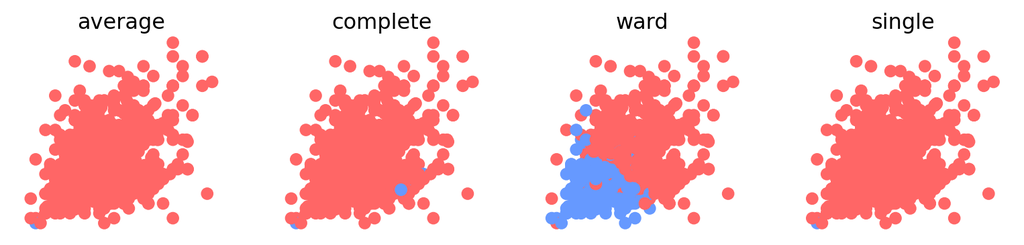

Two clusters using the average, complete, ward, and single linkage methods on Pokémon attack and special attack.

Even when increasing the value of k, there is barely any separation when using average, complete, and single linkage methods, and the cluster assignments are inconsistent across methods. This suggests the data may be somewhat noisy. For the final model, Ward’s linkage is used, as it is generally more effective for handling noisy data.

## Model B: K-means Clustering

K is selected using the silhouette method (identical steps as Model A). A value of $k = 2$ gave the highest average silhouette score of 0.29, and the silhouette plots support this. Comparisons between all clustering models are made at the end.

## Model C: Hierarchical Clustering After PCA

The third model applies agglomerative clustering after principal component analysis. The number of principal components is selected using the elbow method.

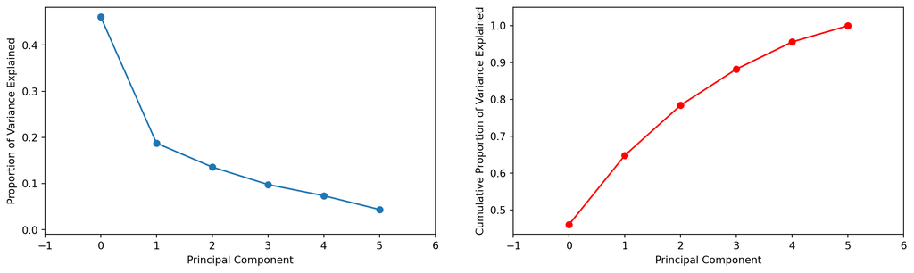

Proportion of variance explained by the number of principal components.

Linear combinations of the original traits for constructing the principal components. {#a94c3d9f}

| HP | Attack | Defense | Sp. Atk | Sp. Def | Speed |
| --- | --- | --- | --- | --- | --- |
| 0.30 | 0.49 | 0.38 | 0.51 | 0.39 | 0.33 |
| 0.04 | 0.08 | 0.70 | -0.38 | 0.17 | -0.58 |
| -0.06 | -0.73 | 0.04 | 0.38 | 0.54 | -0.14 |

Interpretation of each principal component (PC):

- PC1 represents a Pokémon with generally balanced traits with a slight boost in attack.
- PC2 represents a Pokémon with lower special attack and speed but with high defense.
- PC3 represents a Pokémon with low physical attack but high special attack and special defense.

Using the silhouette method again, $k = 2$ is still selected. Similar to Model A, the linkage types do not consistently produce the same clusters, so Ward’s linkage is used.

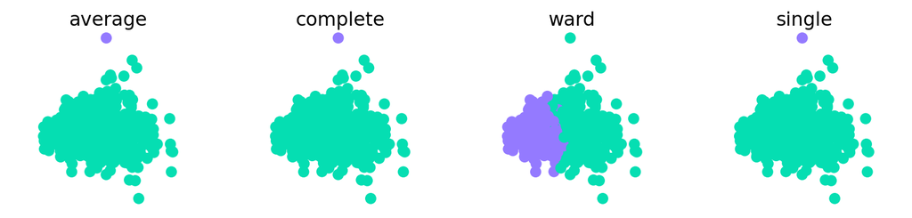

Two clusters using the average, complete, ward, and single linkage methods on the first two principal components.

Ward’s linkage shows a clearer distinction between two clusters compared to the other methods.

## Comparisons Between Models

Interestingly, all three methods suggested $k = 2$. Comparisons are made using the Rand index:

- Between models A and B: Rand index ≈ 0.851.
- Between models A and C: Rand index ≈ 0.853.
- Between models B and C: Rand index ≈ 0.916.

It is interesting that even though models A and C both use agglomerative hierarchical clustering, models B and C are slightly more similar to each other. Nonetheless, all three models are approximately consistent.

## Conclusions

With the cluster assignments established, the natural next question is: what do the two clusters actually represent? The mean trait values within each cluster (using the K-means assignment) are:

Mean battle trait values by cluster (K-means, k = 2). {#2c2b669e}

| Cluster | HP | Attack | Defense | Sp. Atk | Sp. Def | Speed |
| --- | --- | --- | --- | --- | --- | --- |
| Cluster 1 | 81.88 | 97.49 | 89.95 | 90.81 | 88.11 | 80.77 |
| Cluster 2 | 54.88 | 57.94 | 55.50 | 52.33 | 53.44 | 54.04 |

The two clusters separate Pokémon primarily by overall strength. One cluster (n = 426) contains Pokémon with substantially higher average stats across all six traits; the other (n = 374) contains Pokémon with lower averages throughout. This aligns with the PCA result: PC1, which explained the largest share of variance, represents a broadly balanced boost across all traits — so the main axis of variation in the data is simply overall power level, not specialization.

The split makes intuitive sense from a game design perspective. Legendary and pseudo-legendary Pokémon are deliberately designed with higher base stats than common Pokémon, and this structure is strong enough that unsupervised clustering recovers it without any species labels.

## References

Harris, Charles R., K. Jarrod Millman, Stéfan J. van der Walt, Ralf Gommers, Pauli Virtanen, David Cournapeau, Eric Wieser, et al. 2020. “Array Programming with NumPy.” *Nature* 585 (7825): 357–62. https://doi.org/10.1038/s41586-020-2649-2.

Hunter, J. D. 2007. “Matplotlib: A 2D Graphics Environment.” *Computing in Science & Engineering* 9 (3): 90–95. https://doi.org/10.1109/MCSE.2007.55.

Pedregosa, F., G. Varoquaux, A. Gramfort, V. Michel, B. Thirion, O. Grisel, M. Blondel, et al. 2011. “Scikit-Learn: Machine Learning in Python.” *Journal of Machine Learning Research* 12: 2825–30.

Pérez, Fernando, and Brian E. Granger. 2007. “IPython: A System for Interactive Scientific Computing.” *Computing in Science and Engineering* 9 (3): 21–29. https://doi.org/10.1109/MCSE.2007.53.

Team, Pandas Development. 2024. “Pandas-Dev/Pandas: Pandas.” Zenodo. https://doi.org/10.5281/zenodo.13819579.

Virtanen, Pauli, Ralf Gommers, Travis E. Oliphant, Matt Haberland, Tyler Reddy, David Cournapeau, Evgeni Burovski, et al. 2020. “SciPy 1.0: Fundamental Algorithms for Scientific Computing in Python.” *Nature Methods* 17: 261–72. https://doi.org/10.1038/s41592-019-0686-2.

## Supplementary Material

### Setup

```python
import pandas as pd
import numpy as np
import matplotlib as mpl
import matplotlib.pyplot as plt
import matplotlib.cm as cm

from sklearn.preprocessing import scale
from sklearn.decomposition import PCA, TruncatedSVD
from sklearn.cluster import KMeans
from scipy.cluster import hierarchy
from sklearn.cluster import AgglomerativeClustering
from sklearn.metrics import silhouette_samples, silhouette_score
from sklearn.metrics.cluster import rand_score
from IPython.display import display, HTML, Markdown
from tabulate import tabulate
from collections import Counter

DATASET = pd.read_csv("Pokemon.csv")
RAWDATA = pd.read_csv("Pokemon.csv")
columns_for_analysis = ['HP', 'Attack', 'Defense', 'Sp. Atk', 'Sp. Def', 'Speed']
ANALYSIS_DATA = DATASET[columns_for_analysis]

def summary_statistics(df):
    summary = []
    for column in df.columns:
        mean = df[column].mean()
        sd = df[column].std()
        median = df[column].median()
        iqr = df[column].quantile(0.75) - df[column].quantile(0.25)
        min_val = df[column].min()
        max_val = df[column].max()

        summary.append({
            'Trait': column,
            'Mean (SD)': f"{mean:.2f} ({sd:.2f})",
            'Median (IQR)': f"{median:.2f} ({iqr:.2f})",
            'Min': f"{min_val:.2f}",
            'Max': f"{max_val:.2f}"
        })

    return pd.DataFrame(summary)

summary_df = summary_statistics(ANALYSIS_DATA)
display(HTML(f"<div style='text-align: center;'>{summary_df.to_html(index=False)}</div>"))
```

### Code for Model A

```python
sil_scores_a = []
for k in range(2, 11):
    model_poke = AgglomerativeClustering(linkage = "ward", n_clusters = k)
    model_poke.fit(ANALYSIS_DATA)
    score = silhouette_score(ANALYSIS_DATA, model_poke.labels_)
    sil_scores_a.append(score.round(2))
print(sil_scores_a)
```

```
[0.26, 0.22, 0.21, 0.19, 0.2, 0.13, 0.13, 0.13, 0.13]
```

Silhouette plots (without removing potential outliers). Only 4 values of k are shown here; the code can be adapted for more clusters or for Models B and C.

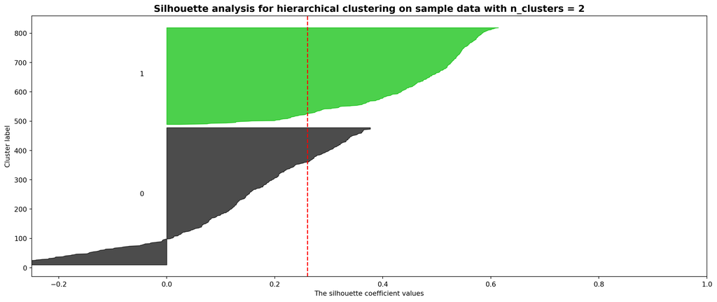

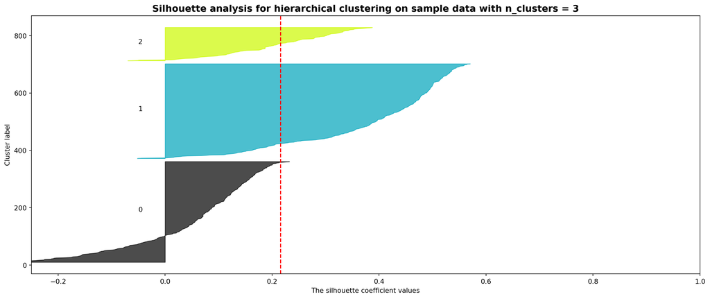

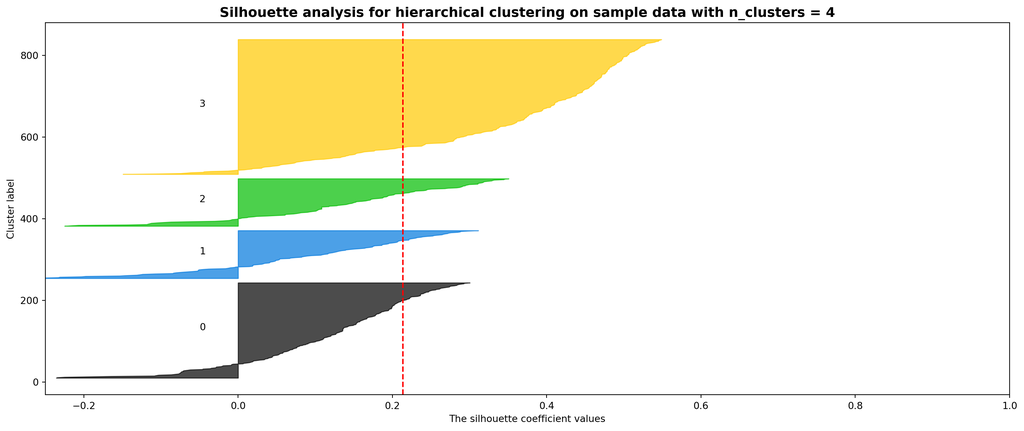

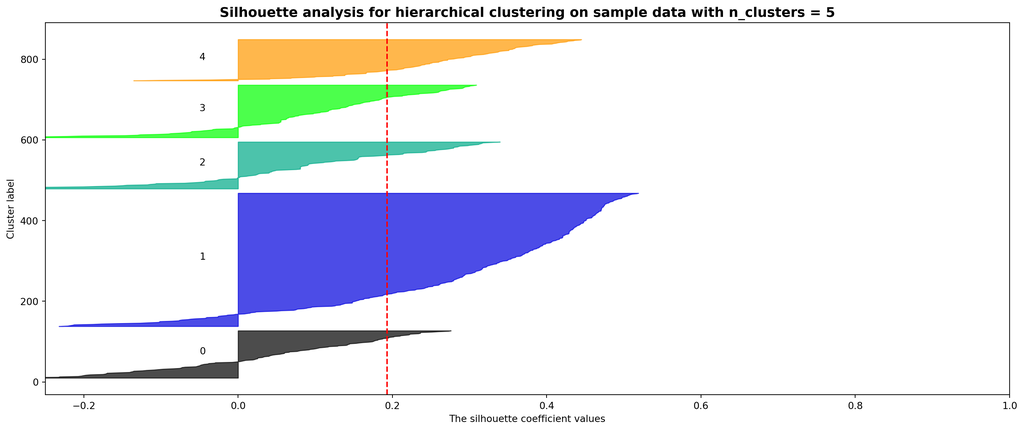

```python
range_n_clusters = range(2, 6)
for n_clusters in range_n_clusters:
    model_poke = AgglomerativeClustering(linkage = "ward", n_clusters = n_clusters)
    model_poke.fit(ANALYSIS_DATA)

    silhouette_avg_psych = silhouette_score(ANALYSIS_DATA, model_poke.labels_)
    sample_silhouette_values = silhouette_samples(ANALYSIS_DATA, model_poke.labels_)

    fig, ax1 = plt.subplots(1, 1)
    fig.set_size_inches(18, 7)
    ax1.set_xlim([-0.25, 1])

    y_lower = 10

    for i in range(n_clusters):
        ith_cluster_silhouette_values = sample_silhouette_values[model_poke.labels_ == i]

        ith_cluster_silhouette_values.sort()
        size_cluster_i = ith_cluster_silhouette_values.shape[0]
        y_upper = y_lower + size_cluster_i

        color = cm.nipy_spectral(float(i) / n_clusters)
        ax1.fill_betweenx(
            np.arange(y_lower, y_upper),
            0,
            ith_cluster_silhouette_values,
            facecolor=color,
            edgecolor=color,
            alpha=0.7,
        )
        ax1.text(-0.05, y_lower + 0.5 * size_cluster_i, str(i))
        y_lower = y_upper + 10

    ax1.set_title("The silhouette plot for various cluster")
    ax1.set_xlabel("The silhouette coefficient values")
    ax1.set_ylabel("Cluster label")

    ax1.axvline(x = silhouette_avg_psych, color="red", linestyle="--")
    plt.title(
        "Silhouette analysis for hierarchical clustering on sample data with n_clusters = %d"
        % n_clusters,
        fontsize=14,
        fontweight="bold",
    )

plt.show()
```

Silhouette plots after attempting to remove outliers:

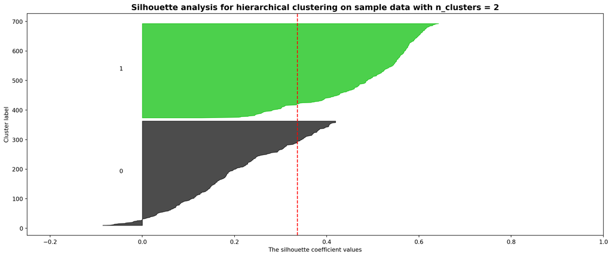

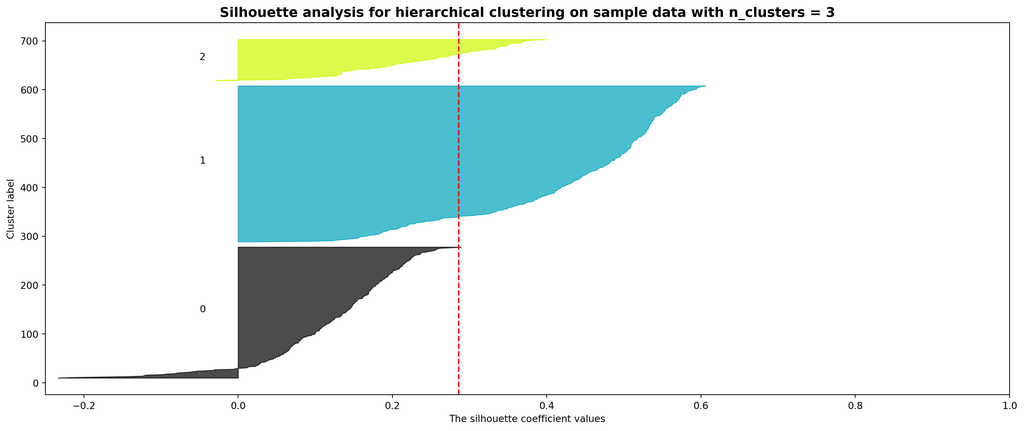

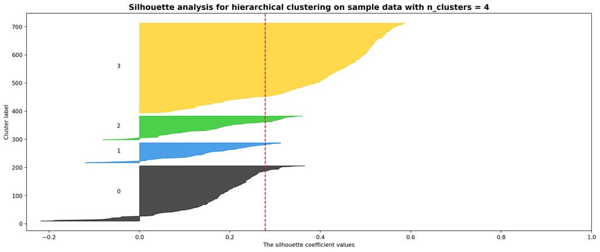

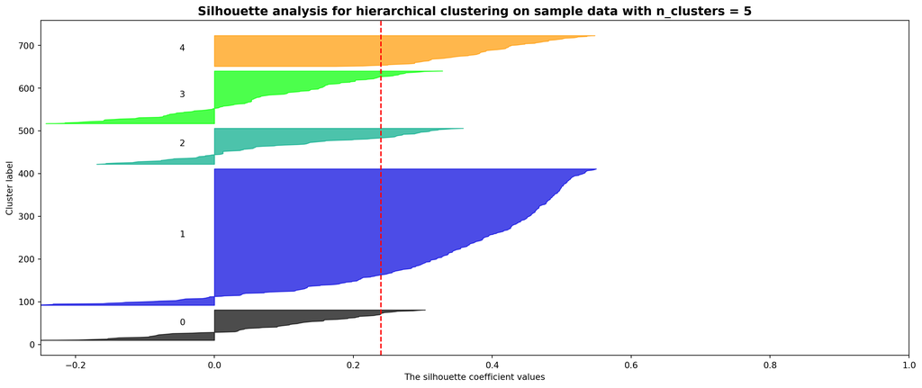

```python
negative_silhouette_names = []

for n_clusters in range(2, 6):
    model_poke = AgglomerativeClustering(linkage="ward", n_clusters=n_clusters)
    model_poke.fit(ANALYSIS_DATA)
    sil_sample = silhouette_samples(ANALYSIS_DATA, model_poke.labels_)
    silhouette_df = pd.DataFrame({
        'Name': RAWDATA['Name'],
        'Silhouette Score': sil_sample
    })
    negative_silhouette_df = silhouette_df[silhouette_df['Silhouette Score'] < 0]
    negative_silhouette_names.extend(negative_silhouette_df['Name'].tolist())

name_counts = Counter(negative_silhouette_names)
names_more = [name for name, count in name_counts.items() if count > 1]

DATASET_2 = ANALYSIS_DATA[~RAWDATA['Name'].isin(names_more)]

range_n_clusters = range(2, 6)
for n_clusters in range_n_clusters:
    model_poke = AgglomerativeClustering(linkage = "ward", n_clusters = n_clusters)
    model_poke.fit(DATASET_2)

    silhouette_avg_psych = silhouette_score(DATASET_2, model_poke.labels_)
    sample_silhouette_values = silhouette_samples(DATASET_2, model_poke.labels_)

    fig, ax1 = plt.subplots(1, 1)
    fig.set_size_inches(18, 7)
    ax1.set_xlim([-0.25, 1])

    y_lower = 10

    for i in range(n_clusters):
        ith_cluster_silhouette_values = sample_silhouette_values[model_poke.labels_ == i]

        ith_cluster_silhouette_values.sort()
        size_cluster_i = ith_cluster_silhouette_values.shape[0]
        y_upper = y_lower + size_cluster_i

        color = cm.nipy_spectral(float(i) / n_clusters)
        ax1.fill_betweenx(
            np.arange(y_lower, y_upper),
            0,
            ith_cluster_silhouette_values,
            facecolor=color,
            edgecolor=color,
            alpha=0.7,
        )
        ax1.text(-0.05, y_lower + 0.5 * size_cluster_i, str(i))
        y_lower = y_upper + 10

    ax1.set_title("The silhouette plot for various cluster")
    ax1.set_xlabel("The silhouette coefficient values")
    ax1.set_ylabel("Cluster label")

    ax1.axvline(x = silhouette_avg_psych, color="red", linestyle="--")
    plt.title(
        "Silhouette analysis for hierarchical clustering on sample data with n_clusters = %d"
        % n_clusters,
        fontsize=14,
        fontweight="bold",
    )

plt.show()
```

Additional comparison of linkage types using attack vs. special attack and defense vs. special defense:

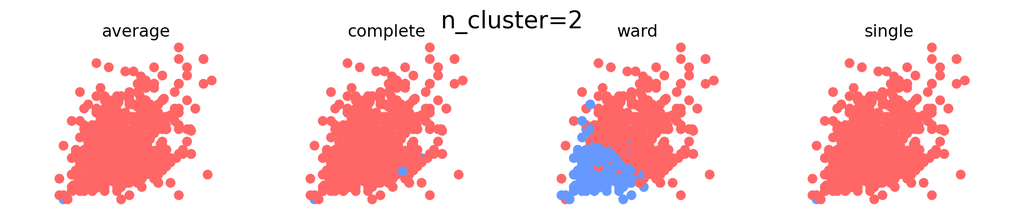

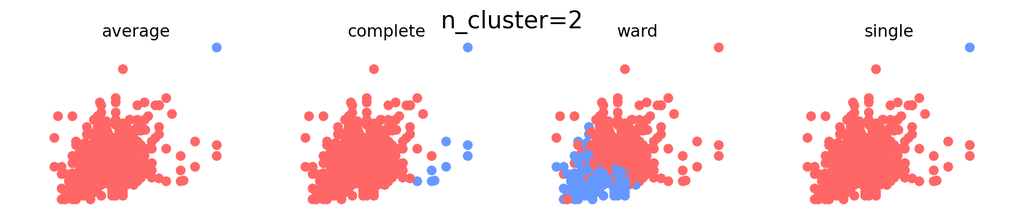

```python
comparisons = [["Attack", "Sp. Atk"], ["Defense", 'Sp. Def']]

colors = np.array(["#FF6666", "#6699FF"])

for m in comparisons:
    plt.figure(figsize=(10, 2))
    for index, linkage in enumerate(("average", "complete", "ward", "single")):
        plt.subplot(1, 4, index + 1)
        model = AgglomerativeClustering(
            linkage = linkage, n_clusters = 2
        )

        model.fit(ANALYSIS_DATA)

        plt.scatter(ANALYSIS_DATA.loc[:, m[0]], ANALYSIS_DATA.loc[:, m[1]], c=colors[model.labels_], cmap=plt.cm.nipy_spectral)
        plt.title((linkage),
            fontdict=dict(verticalalignment="top"),
        )
        plt.axis("equal")
        plt.axis("off")

        plt.subplots_adjust(bottom=0, top=0.83, wspace=0, left=0, right=1)
        plt.suptitle(
            "n_cluster=%i"
            % (2),
            size=17,
        )

plt.show()
```

### Code for Model B

```python
sil_scores_b = []
for k in range(2, 11):
    km_model = KMeans(n_clusters = k, n_init = 20, random_state = 0)
    cluster_labels_km = km_model.fit_predict(ANALYSIS_DATA)
    score = silhouette_score(ANALYSIS_DATA, cluster_labels_km).round(2)
    sil_scores_b.append(score.round(2))
print(sil_scores_b)
```

```
[0.29, 0.26, 0.23, 0.22, 0.22, 0.17, 0.16, 0.15, 0.16]
```

### Code for Model C

```python
pca_comp = PCA()
plot3 = pd.DataFrame(pca_comp.fit_transform(ANALYSIS_DATA))

fig, (ax1,ax2) = plt.subplots(1, 2, figsize=(15, 4))

ax1.plot(pca_comp.explained_variance_ratio_, '-o')
ax1.set_ylabel('Proportion of Variance Explained')
ax1.set_ylim(ymin=-0.01)

ax2.plot(np.cumsum(pca_comp.explained_variance_ratio_), '-ro')
ax2.set_ylabel('Cumulative Proportion of Variance Explained')
ax2.set_ylim(ymax=1.05)

for ax in fig.axes:
    ax.set_xlabel('Principal Component')
    ax.set_xlim(-1,6)

pca_final = PCA(n_components=3)
data_pca = pca_final.fit_transform(ANALYSIS_DATA)
loadings = pca_final.components_
loadings_df = pd.DataFrame(loadings, columns=['HP', 'Attack', 'Defense', 'Sp. Atk', 'Sp. Def', 'Speed'], index=['PC1', 'PC2', 'PC3'])
display(HTML(f"<div style='text-align: center;'>{loadings_df.to_html(index=False)}</div>"))
```

```python
sil_scores_pca = []
for k in range(2, 11):
    model_pca_ver = AgglomerativeClustering(linkage = "ward", n_clusters = k)
    model_pca_ver.fit(data_pca)
    score = silhouette_score(data_pca, model_pca_ver.labels_)
    sil_scores_pca.append(score.round(2))
print(sil_scores_pca)
```

```
[0.35, 0.33, 0.29, 0.28, 0.22, 0.19, 0.19, 0.2, 0.2]
```

### Code for Comparisons

```python
model_poke_agg = AgglomerativeClustering(linkage = "ward", n_clusters = 2)
model_poke_agg.fit(ANALYSIS_DATA)
model_poke_kmeans = KMeans(n_clusters = 2, n_init = 20, random_state = 0)
model_poke_kmeans.fit(ANALYSIS_DATA)
pca_agg_model = AgglomerativeClustering(linkage = "ward", n_clusters=2)
pca_agg_labs = pca_agg_model.fit_predict(data_pca)
comparison1 = rand_score(model_poke_agg.labels_, model_poke_kmeans.labels_)
comparison2 = rand_score(model_poke_agg.labels_, pca_agg_labs)
comparison3 = rand_score(model_poke_kmeans.labels_, pca_agg_labs)
print(f"compare A and B: {comparison1}")
print(f"compare A and C: {comparison2}")
print(f"compare B and C: {comparison3}")
```

```
compare A and B: 0.8505162703379224
compare A and C: 0.8526157697121401
compare B and C: 0.9162234042553191
```